# ST 495 HW8

Eric Warren

2022-10-20

## Honor Code

I have neither given nor received unauthorized assistance on this test or assignment. -**Eric Warren**

### Problem 1

#### Part A

Using hierarchical clustering with complete linkage and Euclidean distance, cluster the states using `USArrests` data.

```r
library(ISLR)
library(tidyverse)
head(USArrests) # Look at initial things for the data
```

```
##            Murder Assault UrbanPop Rape
## Alabama      13.2     236       58 21.2
## Alaska       10.0     263       48 44.5
## Arizona       8.1     294       80 31.0
## Arkansas      8.8     190       50 19.5
## California    9.0     276       91 40.6
## Colorado      7.9     204       78 38.7
```

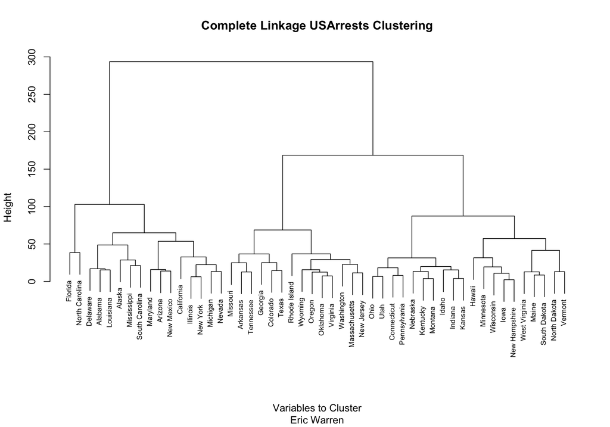

```r
# Do the clustering
arrests_hc_complete <- hclust(dist(USArrests, method = "euclidean"),
                              method = "complete")

# Plot the clustering
plot(arrests_hc_complete,
     main = "Complete Linkage USArrests Clustering",
     xlab = "Variables to Cluster",
     sub = "Eric Warren",
     cex = .69)
```

Here we can see some states that are clustered together. For example, Florida and North Carolina are very similar.

#### Part B

Cut the dendrogram at a height that results in three distinct clusters.

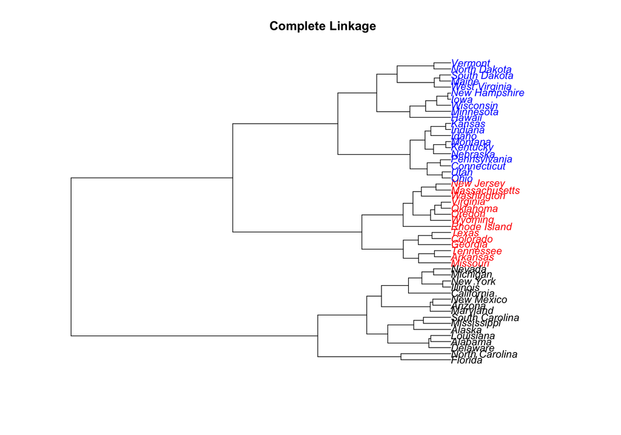

```r
arrest_clusters <- cutree(arrests_hc_complete, 3)

# This pulls out the names of the states
cluster_1 <- arrest_clusters[arrest_clusters == 1]
cluster_2 <- arrest_clusters[arrest_clusters == 2]
cluster_3 <- arrest_clusters[arrest_clusters == 3]

# Plot the clustering
library(ape)
colorsUsed = c("black", "red", "blue")
plot(as.phylo(arrests_hc_complete),
     tip.color = colorsUsed[cutree(arrests_hc_complete, 3)],
     main = "Complete Linkage")
```

Here we can see the three clusters that are present based on their arrest statistics. The first cluster includes the states of Alabama, Alaska, Arizona, California, Delaware, Florida, Illinois, Louisiana, Maryland, Michigan, Mississippi, Nevada, New Mexico, New York, North Carolina, South Carolina. The second cluster includes the states of Arkansas, Colorado, Georgia, Massachusetts, Missouri, New Jersey, Oklahoma, Oregon, Rhode Island, Tennessee, Texas, Virginia, Washington, Wyoming. Lastly, the third cluster includes the states of Connecticut, Hawaii, Idaho, Indiana, Iowa, Kansas, Kentucky, Maine, Minnesota, Montana, Nebraska, New Hampshire, North Dakota, Ohio, Pennsylvania, South Dakota, Utah, Vermont, West Virginia, Wisconsin.

#### Part C

Hierarchically cluster the states using complete linkage and Euclidean distance, after scaling the variables to have standard deviation one.

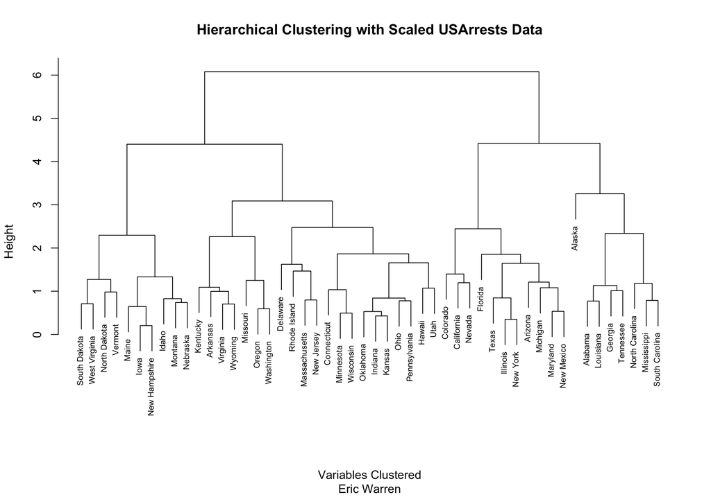

```r
arrests_scaled <- scale(USArrests)
clusters_scaled <- hclust(dist(arrests_scaled, method = "euclidean"),
                          method = "complete")
plot(clusters_scaled,
     main = "Hierarchical Clustering with Scaled USArrests Data",
     xlab = "Variables Clustered",
     sub = "Eric Warren",
     cex = .69)
```

Now we can see how some states are very similar when modeled like this. For example, Iowa and New Hampshire are very similar. Meanwhile, Alaska is not similar to many states.

#### Part D

We are going to compare the non-scaled vs. scaled clustering.

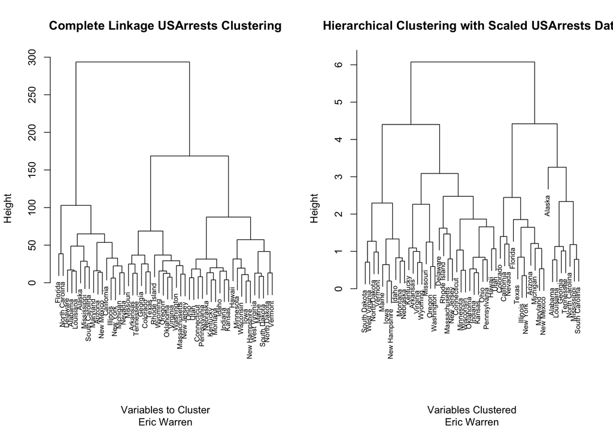

```r
par(mfrow = c(1, 2))
plot(arrests_hc_complete,
     main = "Complete Linkage USArrests Clustering",
     xlab = "Variables to Cluster",
     sub = "Eric Warren",
     cex = .69)
plot(clusters_scaled,
     main = "Hierarchical Clustering with Scaled USArrests Data",
     xlab = "Variables Clustered",
     sub = "Eric Warren",
     cex = .69)
```

What effect does scaling the variables have on the hierarchical clustering obtained? - Scaling the variables makes outliers and differences show more. When having everything on a scale, these differences as the same weight across all the predictor variables. Also, without scaling variables like `Assault` will have a larger say on the groups since its value is much higher. Scaling eliminates this problem.

In your opinion, should the variables be scaled before the inter-observation dissimilarities are computed? - I believe the variables should be scaled before finding groups because everything will be equally weighted; moreover, the `Assault` variable will not have a bigger influence on the groups. If the variables had the same scales then scaling would not be necessary but in this case where they are very different scaling is needed.

### Problem 2

#### Part A

Generate a simulated data set with 20 observations in each of three classes (i.e. 60 observations total), and 50 variables.

```r
set.seed(9)
random_data <- rbind(matrix(rnorm(20*50, mean = 0), nrow = 20),
                     matrix(rnorm(20*50, mean = 0.9), nrow = 20),
                     matrix(rnorm(20*50, mean = -0.9), nrow = 20))
```

#### Part B

Perform PCA on the 60 observations and plot the first two principal component score vectors. Use a different color to indicate the observations in each of the three classes. If the three classes appear separated in this plot, then continue on to part (c). If not, then return to part (a) and modify the simulation so that there is greater separation between the three classes. Do not continue to part (c) until the three classes show at least some separation in the first two principal component score vectors.

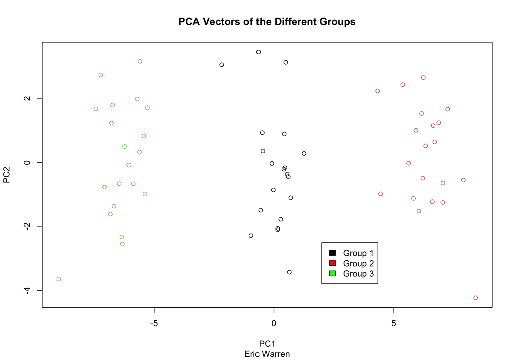

```r
pca_data <- prcomp(random_data)$x

group1 <- rep(1, 20)
group2 <- rep(2, 20)
group3 <- rep(3, 20)
plot(pca_data[ , 1:2],
     col = c(group1, group2, group3),
     main = "PCA Vectors of the Different Groups",
     sub = "Eric Warren")
legend(2, -2.5, legend = c("Group 1", "Group 2", "Group 3"),
       fill = c("black","red", "green")
)
```

Here we can see the three distinct different groups of data that we have.

#### Part C

Perform K-means clustering of the observations with K = 3. How well do the clusters that you obtained in K-means clustering compare to the true class labels?

```r
k_means_data <- kmeans(random_data, centers = 3)
true_group <- c(group1, group2, group3)
table(k_means_data$cluster, true_group)
```

```
##    true_group
##      1  2  3
##   1 20  0  0
##   2  0 20  0
##   3  0  0 20
```

As we can see all groups are perfectly clustered.

#### Part D

Perform K-means clustering with K = 2.

```r
k_means_data <- kmeans(random_data, centers = 2)
table(k_means_data$cluster, true_group)
```

```
##    true_group
##      1  2  3
##   1 19 20  0
##   2  1  0 20
```

In the case of this data, We can see that the two extremes are separated from each other and then the middle group is mostly going with the positive value side rather than the other.

#### Part E

Perform K-means clustering with K = 4.

```r
k_means_data <- kmeans(random_data, centers = 4)
table(k_means_data$cluster, true_group)
```

```
##    true_group
##      1  2  3
##   1  0  0 11
##   2 19 20  0
##   3  1  0  5
##   4  0  0  4
```

We can see that most of the observations are in two clusters while the last two seem like they are not really needed.

#### Part F

Now perform K-means clustering with K = 3 on the first two principal component score vectors, rather than on the raw data. That is, perform K-means clustering on the 60 × 2 matrix of which the first column is the first principal component score vector, and the second column is the second principal component score vector.

```r
k_means_data <- kmeans(pca_data[, 1:2], centers = 3)
table(k_means_data$cluster, true_group)
```

```
##    true_group
##      1  2  3
##   1  0  0 20
##   2 20  0  0
##   3  0 20  0
```

As we can see, the groups are perfectly separated again.

#### Part G

Using the `scale()` function, perform K-means clustering with K = 3 on the data after scaling each variable to have standard deviation one.

```r
set.seed(9)
k_means_data <- kmeans(scale(random_data), centers = 3)
table(k_means_data$cluster, true_group)
```

```
##    true_group
##      1  2  3
##   1  1  0 15
##   2  0  0  5
##   3 19 20  0
```

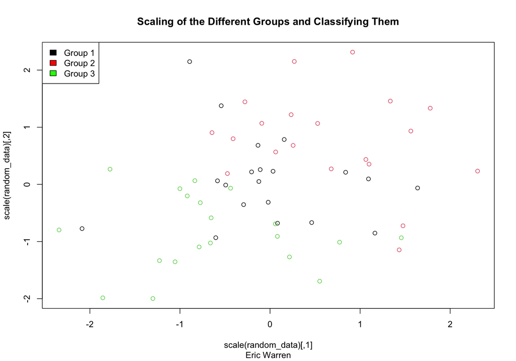

```r
plot(scale(random_data),
     col = c(group1, group2, group3),
     main = "Scaling of the Different Groups and Classifying Them",
     sub = "Eric Warren")
legend("topleft", legend = c("Group 1", "Group 2", "Group 3"),
       fill = c("black", "red", "green"))
```

### Problem 3

#### Make Function

Here we are going to make a function we can use based on algorithm 12.1.

```r
fit.svd <- function(x, m = 1) {
   svdob <- svd(x)
   with(svdob,
       u[ , 1:m, drop = FALSE] %*%
       (d[1:m] * t(v[, 1:m, drop = FALSE]))
     )
}
```

#### Test With Boston Data

Here we are going to use the `Boston` data to start our analysis.

```r
library(MASS)
scaled_boston <- data.matrix(scale(Boston))
```

##### 5% Omit Rate

Here we will keep track of our error rates and number of iterations. This is for 5%.

```r
# Omit number of variables
nomit <- round(.05 * nrow(scaled_boston), 0)
set.seed(9)
ina <- sample(nrow(scaled_boston), nomit)
inb <- sample(1:ncol(scaled_boston), nomit, replace = TRUE)
Xna <- scaled_boston
index.na <- cbind(ina, inb)
Xna[index.na] <- NA

# Initialize xhat
Xhat <- Xna
xbar <- colMeans(Xna, na.rm = TRUE)
Xhat[index.na] <- xbar[inb]

# Initialize thresholds
thresh <- 1e-7
rel_err <- 1
iter <- 0
ismiss <- is.na(Xna)
mssold <- mean((scale(Xna, xbar, FALSE)[!ismiss])^2)
mss0 <- mean(Xna[!ismiss]^2)

while(rel_err > thresh) {
    iter <- iter + 1
    # Step 2(a)
    Xapp <- fit.svd(Xhat, m = 8)
    # Step 2(b)
    Xhat[ismiss] <- Xapp[ismiss]
    # Step 2(c)
    mss <- mean(((Xna - Xapp)[!ismiss])^2)
    rel_err <- (mssold - mss) / mss0
    mssold <- mss
    cat("Iter:", iter, "MSS:", mss,
      "Rel. Err:", rel_err, "\n")
    rel_err_5 <- data.frame(iter, mss, rel_err)
    rel_err_5$missing_percent <- .05
    }
```

```
## Iter: 1 MSS: 0.08027708 Rel. Err: 0.9195978
## Iter: 2 MSS: 0.0798849 Rel. Err: 0.0003927689
## Iter: 3 MSS: 0.0797693 Rel. Err: 0.0001157719
## Iter: 4 MSS: 0.07971994 Rel. Err: 4.943252e-05
## Iter: 5 MSS: 0.07969529 Rel. Err: 2.468383e-05
## Iter: 6 MSS: 0.07968186 Rel. Err: 1.345038e-05
## Iter: 7 MSS: 0.07967396 Rel. Err: 7.91107e-06
## Iter: 8 MSS: 0.07966895 Rel. Err: 5.024369e-06
## Iter: 9 MSS: 0.07966551 Rel. Err: 3.436498e-06
## Iter: 10 MSS: 0.07966301 Rel. Err: 2.510354e-06
## Iter: 11 MSS: 0.07966107 Rel. Err: 1.935552e-06
## Iter: 12 MSS: 0.07965952 Rel. Err: 1.556026e-06
## Iter: 13 MSS: 0.07965823 Rel. Err: 1.290599e-06
## Iter: 14 MSS: 0.07965714 Rel. Err: 1.095423e-06
## Iter: 15 MSS: 0.07965619 Rel. Err: 9.45816e-07
## Iter: 16 MSS: 0.07965537 Rel. Err: 8.272606e-07
## Iter: 17 MSS: 0.07965464 Rel. Err: 7.308252e-07
## Iter: 18 MSS: 0.07965399 Rel. Err: 6.507671e-07
## Iter: 19 MSS: 0.07965341 Rel. Err: 5.832351e-07
## Iter: 20 MSS: 0.07965288 Rel. Err: 5.255444e-07
## Iter: 21 MSS: 0.07965241 Rel. Err: 4.757568e-07
## Iter: 22 MSS: 0.07965197 Rel. Err: 4.324293e-07
## Iter: 23 MSS: 0.07965158 Rel. Err: 3.944583e-07
## Iter: 24 MSS: 0.07965122 Rel. Err: 3.609809e-07
## Iter: 25 MSS: 0.07965089 Rel. Err: 3.313091e-07
## Iter: 26 MSS: 0.07965059 Rel. Err: 3.04886e-07
## Iter: 27 MSS: 0.0796503 Rel. Err: 2.812544e-07
## Iter: 28 MSS: 0.07965004 Rel. Err: 2.600354e-07
## Iter: 29 MSS: 0.0796498 Rel. Err: 2.409123e-07
## Iter: 30 MSS: 0.07964958 Rel. Err: 2.236182e-07
## Iter: 31 MSS: 0.07964937 Rel. Err: 2.079267e-07
## Iter: 32 MSS: 0.07964918 Rel. Err: 1.936455e-07
## Iter: 33 MSS: 0.079649 Rel. Err: 1.806096e-07
## Iter: 34 MSS: 0.07964883 Rel. Err: 1.686775e-07
## Iter: 35 MSS: 0.07964867 Rel. Err: 1.577274e-07
## Iter: 36 MSS: 0.07964853 Rel. Err: 1.476537e-07
## Iter: 37 MSS: 0.07964839 Rel. Err: 1.38365e-07
## Iter: 38 MSS: 0.07964826 Rel. Err: 1.297816e-07
## Iter: 39 MSS: 0.07964814 Rel. Err: 1.218341e-07
## Iter: 40 MSS: 0.07964802 Rel. Err: 1.144615e-07
## Iter: 41 MSS: 0.07964792 Rel. Err: 1.076104e-07
## Iter: 42 MSS: 0.07964781 Rel. Err: 1.012338e-07
## Iter: 43 MSS: 0.07964772 Rel. Err: 9.528988e-08
```

##### 10% Omit Rate

Here we will keep track of our error rates and number of iterations. This is for 10%.

```r
# Omit number of variables
nomit <- round(.10 * nrow(scaled_boston), 0)
set.seed(9)
ina <- sample(nrow(scaled_boston), nomit)
inb <- sample(1:ncol(scaled_boston), nomit, replace = TRUE)
Xna <- scaled_boston
index.na <- cbind(ina, inb)
Xna[index.na] <- NA

# Initialize xhat
Xhat <- Xna
xbar <- colMeans(Xna, na.rm = TRUE)
Xhat[index.na] <- xbar[inb]

# Initialize thresholds
thresh <- 1e-7
rel_err <- 1
iter <- 0
ismiss <- is.na(Xna)
mssold <- mean((scale(Xna, xbar, FALSE)[!ismiss])^2)
mss0 <- mean(Xna[!ismiss]^2)

while(rel_err > thresh) {
    iter <- iter + 1
    # Step 2(a)
    Xapp <- fit.svd(Xhat, m = 8)
    # Step 2(b)
    Xhat[ismiss] <- Xapp[ismiss]
    # Step 2(c)
    mss <- mean(((Xna - Xapp)[!ismiss])^2)
    rel_err <- (mssold - mss) / mss0
    mssold <- mss
    cat("Iter:", iter, "MSS:", mss,
      "Rel. Err:", rel_err, "\n")
    rel_err_10 <- data.frame(iter, mss, rel_err)
    rel_err_10$missing_percent <- .10
    }
```

```
## Iter: 1 MSS: 0.08088882 Rel. Err: 0.9189634
## Iter: 2 MSS: 0.08005068 Rel. Err: 0.0008395521
## Iter: 3 MSS: 0.07981619 Rel. Err: 0.0002348779
## Iter: 4 MSS: 0.07971414 Rel. Err: 0.0001022174
## Iter: 5 MSS: 0.07965389 Rel. Err: 6.035154e-05
## Iter: 6 MSS: 0.07961202 Rel. Err: 4.194753e-05
## Iter: 7 MSS: 0.07958035 Rel. Err: 3.171809e-05
## Iter: 8 MSS: 0.07955528 Rel. Err: 2.511574e-05
## Iter: 9 MSS: 0.07953487 Rel. Err: 2.043745e-05
## Iter: 10 MSS: 0.07951798 Rel. Err: 1.692432e-05
## Iter: 11 MSS: 0.07950381 Rel. Err: 1.418879e-05
## Iter: 12 MSS: 0.07949182 Rel. Err: 1.200887e-05
## Iter: 13 MSS: 0.0794816 Rel. Err: 1.024456e-05
## Iter: 14 MSS: 0.07947281 Rel. Err: 8.800744e-06
## Iter: 15 MSS: 0.07946521 Rel. Err: 7.609156e-06
## Iter: 16 MSS: 0.07945861 Rel. Err: 6.618907e-06
## Iter: 17 MSS: 0.07945282 Rel. Err: 5.791067e-06
## Iter: 18 MSS: 0.07944774 Rel. Err: 5.095304e-06
## Iter: 19 MSS: 0.07944324 Rel. Err: 4.507674e-06
## Iter: 20 MSS: 0.07943924 Rel. Err: 4.009082e-06
## Iter: 21 MSS: 0.07943566 Rel. Err: 3.584181e-06
## Iter: 22 MSS: 0.07943244 Rel. Err: 3.22055e-06
## Iter: 23 MSS: 0.07942954 Rel. Err: 2.908083e-06
## Iter: 24 MSS: 0.0794269 Rel. Err: 2.638511e-06
## Iter: 25 MSS: 0.0794245 Rel. Err: 2.405039e-06
## Iter: 26 MSS: 0.07942231 Rel. Err: 2.202059e-06
## Iter: 27 MSS: 0.07942028 Rel. Err: 2.024923e-06
## Iter: 28 MSS: 0.07941842 Rel. Err: 1.869767e-06
## Iter: 29 MSS: 0.07941669 Rel. Err: 1.733365e-06
## Iter: 30 MSS: 0.07941508 Rel. Err: 1.613014e-06
## Iter: 31 MSS: 0.07941357 Rel. Err: 1.506446e-06
## Iter: 32 MSS: 0.07941216 Rel. Err: 1.411748e-06
## Iter: 33 MSS: 0.07941084 Rel. Err: 1.327302e-06
## Iter: 34 MSS: 0.07940959 Rel. Err: 1.251739e-06
## Iter: 35 MSS: 0.07940841 Rel. Err: 1.183893e-06
## Iter: 36 MSS: 0.07940729 Rel. Err: 1.122771e-06
## Iter: 37 MSS: 0.07940622 Rel. Err: 1.067525e-06
## Iter: 38 MSS: 0.0794052 Rel. Err: 1.017429e-06
## Iter: 39 MSS: 0.07940423 Rel. Err: 9.718564e-07
## Iter: 40 MSS: 0.07940331 Rel. Err: 9.302711e-07
```

[output cut: 193 more lines]

```
## Iter: 234 MSS: 0.07935205 Rel. Err: 1.07978e-07
## Iter: 235 MSS: 0.07935194 Rel. Err: 1.073541e-07
## Iter: 236 MSS: 0.07935183 Rel. Err: 1.067346e-07
## Iter: 237 MSS: 0.07935173 Rel. Err: 1.061194e-07
## Iter: 238 MSS: 0.07935162 Rel. Err: 1.055086e-07
## Iter: 239 MSS: 0.07935152 Rel. Err: 1.049021e-07
## Iter: 240 MSS: 0.07935141 Rel. Err: 1.042998e-07
## Iter: 241 MSS: 0.07935131 Rel. Err: 1.037018e-07
## Iter: 242 MSS: 0.07935121 Rel. Err: 1.031078e-07
## Iter: 243 MSS: 0.0793511 Rel. Err: 1.025181e-07
## Iter: 244 MSS: 0.079351 Rel. Err: 1.019323e-07
## Iter: 245 MSS: 0.0793509 Rel. Err: 1.013507e-07
## Iter: 246 MSS: 0.0793508 Rel. Err: 1.00773e-07
## Iter: 247 MSS: 0.0793507 Rel. Err: 1.001993e-07
## Iter: 248 MSS: 0.0793506 Rel. Err: 9.962945e-08
```

##### 15% Omit Rate

Here we will keep track of our error rates and number of iterations. This is for 15%.

```r
# Omit number of variables
nomit <- round(.15 * nrow(scaled_boston), 0)
set.seed(9)
ina <- sample(nrow(scaled_boston), nomit)
inb <- sample(1:ncol(scaled_boston), nomit, replace = TRUE)
Xna <- scaled_boston
index.na <- cbind(ina, inb)
Xna[index.na] <- NA

# Initialize xhat
Xhat <- Xna
xbar <- colMeans(Xna, na.rm = TRUE)
Xhat[index.na] <- xbar[inb]

# Initialize thresholds
thresh <- 1e-7
rel_err <- 1
iter <- 0
ismiss <- is.na(Xna)
mssold <- mean((scale(Xna, xbar, FALSE)[!ismiss])^2)
mss0 <- mean(Xna[!ismiss]^2)

while(rel_err > thresh) {
    iter <- iter + 1
    # Step 2(a)
    Xapp <- fit.svd(Xhat, m = 8)
    # Step 2(b)
    Xhat[ismiss] <- Xapp[ismiss]
    # Step 2(c)
    mss <- mean(((Xna - Xapp)[!ismiss])^2)
    rel_err <- (mssold - mss) / mss0
    mssold <- mss
    cat("Iter:", iter, "MSS:", mss,
      "Rel. Err:", rel_err, "\n")
    rel_err_15 <- data.frame(iter, mss, rel_err)
    rel_err_15$missing_percent <- .15
    }
```

```
## Iter: 1 MSS: 0.08007637 Rel. Err: 0.919825
## Iter: 2 MSS: 0.07886151 Rel. Err: 0.001215994
## Iter: 3 MSS: 0.07860128 Rel. Err: 0.0002604799
## Iter: 4 MSS: 0.07850193 Rel. Err: 9.944366e-05
## Iter: 5 MSS: 0.07844376 Rel. Err: 5.82204e-05
## Iter: 6 MSS: 0.07840219 Rel. Err: 4.161324e-05
## Iter: 7 MSS: 0.07836965 Rel. Err: 3.256889e-05
## Iter: 8 MSS: 0.0783429 Rel. Err: 2.677708e-05
## Iter: 9 MSS: 0.07832022 Rel. Err: 2.270317e-05
## Iter: 10 MSS: 0.07830058 Rel. Err: 1.965419e-05
## Iter: 11 MSS: 0.07828333 Rel. Err: 1.726951e-05
## Iter: 12 MSS: 0.078268 Rel. Err: 1.534331e-05
## Iter: 13 MSS: 0.07825426 Rel. Err: 1.374949e-05
## Iter: 14 MSS: 0.07824187 Rel. Err: 1.240622e-05
## Iter: 15 MSS: 0.07823062 Rel. Err: 1.125774e-05
## Iter: 16 MSS: 0.07822037 Rel. Err: 1.026447e-05
## Iter: 17 MSS: 0.07821098 Rel. Err: 9.397354e-06
## Iter: 18 MSS: 0.07820235 Rel. Err: 8.634452e-06
## Iter: 19 MSS: 0.0781944 Rel. Err: 7.958809e-06
## Iter: 20 MSS: 0.07818705 Rel. Err: 7.357057e-06
## Iter: 21 MSS: 0.07818024 Rel. Err: 6.818481e-06
## Iter: 22 MSS: 0.07817391 Rel. Err: 6.334368e-06
## Iter: 23 MSS: 0.07816802 Rel. Err: 5.897541e-06
## Iter: 24 MSS: 0.07816252 Rel. Err: 5.502028e-06
## Iter: 25 MSS: 0.07815738 Rel. Err: 5.142813e-06
## Iter: 26 MSS: 0.07815257 Rel. Err: 4.815643e-06
## Iter: 27 MSS: 0.07814806 Rel. Err: 4.516889e-06
## Iter: 28 MSS: 0.07814382 Rel. Err: 4.243433e-06
## Iter: 29 MSS: 0.07813983 Rel. Err: 3.992582e-06
## Iter: 30 MSS: 0.07813607 Rel. Err: 3.761993e-06
## Iter: 31 MSS: 0.07813253 Rel. Err: 3.549622e-06
## Iter: 32 MSS: 0.07812917 Rel. Err: 3.353678e-06
## Iter: 33 MSS: 0.07812601 Rel. Err: 3.172581e-06
## Iter: 34 MSS: 0.078123 Rel. Err: 3.004939e-06
## Iter: 35 MSS: 0.07812016 Rel. Err: 2.849515e-06
## Iter: 36 MSS: 0.07811745 Rel. Err: 2.705209e-06
## Iter: 37 MSS: 0.07811488 Rel. Err: 2.571041e-06
## Iter: 38 MSS: 0.07811244 Rel. Err: 2.446135e-06
## Iter: 39 MSS: 0.07811011 Rel. Err: 2.329705e-06
## Iter: 40 MSS: 0.07810789 Rel. Err: 2.221043e-06
```

[output cut: 157 more lines]

```
## Iter: 198 MSS: 0.07803228 Rel. Err: 1.157142e-07
## Iter: 199 MSS: 0.07803217 Rel. Err: 1.144871e-07
## Iter: 200 MSS: 0.07803206 Rel. Err: 1.132751e-07
## Iter: 201 MSS: 0.07803194 Rel. Err: 1.12078e-07
## Iter: 202 MSS: 0.07803183 Rel. Err: 1.108956e-07
## Iter: 203 MSS: 0.07803172 Rel. Err: 1.097275e-07
## Iter: 204 MSS: 0.07803161 Rel. Err: 1.085737e-07
## Iter: 205 MSS: 0.07803151 Rel. Err: 1.074339e-07
## Iter: 206 MSS: 0.0780314 Rel. Err: 1.063078e-07
## Iter: 207 MSS: 0.0780313 Rel. Err: 1.051953e-07
## Iter: 208 MSS: 0.07803119 Rel. Err: 1.040962e-07
## Iter: 209 MSS: 0.07803109 Rel. Err: 1.030103e-07
## Iter: 210 MSS: 0.07803099 Rel. Err: 1.019374e-07
## Iter: 211 MSS: 0.07803089 Rel. Err: 1.008773e-07
## Iter: 212 MSS: 0.07803079 Rel. Err: 9.982978e-08
```

##### 20% Omit Rate

Here we will keep track of our error rates and number of iterations. This is for 20%.

```r
# Omit number of variables
nomit <- round(.20 * nrow(scaled_boston), 0)
set.seed(9)
ina <- sample(nrow(scaled_boston), nomit)
inb <- sample(1:ncol(scaled_boston), nomit, replace = TRUE)
Xna <- scaled_boston
index.na <- cbind(ina, inb)
Xna[index.na] <- NA

# Initialize xhat
Xhat <- Xna
xbar <- colMeans(Xna, na.rm = TRUE)
Xhat[index.na] <- xbar[inb]

# Initialize thresholds
thresh <- 1e-7
rel_err <- 1
iter <- 0
ismiss <- is.na(Xna)
mssold <- mean((scale(Xna, xbar, FALSE)[!ismiss])^2)
mss0 <- mean(Xna[!ismiss]^2)

while(rel_err > thresh) {
    iter <- iter + 1
    # Step 2(a)
    Xapp <- fit.svd(Xhat, m = 8)
    # Step 2(b)
    Xhat[ismiss] <- Xapp[ismiss]
    # Step 2(c)
    mss <- mean(((Xna - Xapp)[!ismiss])^2)
    rel_err <- (mssold - mss) / mss0
    mssold <- mss
    cat("Iter:", iter, "MSS:", mss,
      "Rel. Err:", rel_err, "\n")
    rel_err_20 <- data.frame(iter, mss, rel_err)
    rel_err_20$missing_percent <- .20
    }
```

```
## Iter: 1 MSS: 0.08140127 Rel. Err: 0.9183412
## Iter: 2 MSS: 0.07924923 Rel. Err: 0.002157863
## Iter: 3 MSS: 0.07871928 Rel. Err: 0.0005313781
## Iter: 4 MSS: 0.07851476 Rel. Err: 0.0002050704
## Iter: 5 MSS: 0.07840286 Rel. Err: 0.0001122015
## Iter: 6 MSS: 0.07832847 Rel. Err: 7.459722e-05
## Iter: 7 MSS: 0.07827359 Rel. Err: 5.502677e-05
## Iter: 8 MSS: 0.07823061 Rel. Err: 4.309389e-05
## Iter: 9 MSS: 0.07819568 Rel. Err: 3.502212e-05
## Iter: 10 MSS: 0.0781666 Rel. Err: 2.916187e-05
## Iter: 11 MSS: 0.07814197 Rel. Err: 2.469696e-05
## Iter: 12 MSS: 0.07812084 Rel. Err: 2.118237e-05
## Iter: 13 MSS: 0.07810254 Rel. Err: 1.835376e-05
## Iter: 14 MSS: 0.07808654 Rel. Err: 1.60417e-05
## Iter: 15 MSS: 0.07807245 Rel. Err: 1.413034e-05
## Iter: 16 MSS: 0.07805995 Rel. Err: 1.253636e-05
## Iter: 17 MSS: 0.07804878 Rel. Err: 1.119753e-05
## Iter: 18 MSS: 0.07803874 Rel. Err: 1.006608e-05
## Iter: 19 MSS: 0.07802966 Rel. Err: 9.104625e-06
## Iter: 20 MSS: 0.0780214 Rel. Err: 8.283465e-06
## Iter: 21 MSS: 0.07801384 Rel. Err: 7.578767e-06
## Iter: 22 MSS: 0.07800689 Rel. Err: 6.971237e-06
## Iter: 23 MSS: 0.07800046 Rel. Err: 6.445153e-06
## Iter: 24 MSS: 0.07799449 Rel. Err: 5.987623e-06
## Iter: 25 MSS: 0.07798892 Rel. Err: 5.588026e-06
## Iter: 26 MSS: 0.07798369 Rel. Err: 5.237572e-06
## Iter: 27 MSS: 0.07797878 Rel. Err: 4.928951e-06
## Iter: 28 MSS: 0.07797413 Rel. Err: 4.656067e-06
## Iter: 29 MSS: 0.07796973 Rel. Err: 4.413811e-06
## Iter: 30 MSS: 0.07796554 Rel. Err: 4.19789e-06
## Iter: 31 MSS: 0.07796155 Rel. Err: 4.004684e-06
## Iter: 32 MSS: 0.07795773 Rel. Err: 3.83113e-06
## Iter: 33 MSS: 0.07795406 Rel. Err: 3.674627e-06
## Iter: 34 MSS: 0.07795054 Rel. Err: 3.532965e-06
## Iter: 35 MSS: 0.07794715 Rel. Err: 3.404253e-06
## Iter: 36 MSS: 0.07794387 Rel. Err: 3.286876e-06
## Iter: 37 MSS: 0.0779407 Rel. Err: 3.179446e-06
## Iter: 38 MSS: 0.07793762 Rel. Err: 3.08077e-06
## Iter: 39 MSS: 0.07793464 Rel. Err: 2.989818e-06
## Iter: 40 MSS: 0.07793175 Rel. Err: 2.9057e-06
```

[output cut: 1183 more lines]

```
## Iter: 1224 MSS: 0.07721101 Rel. Err: 1.024756e-07
## Iter: 1225 MSS: 0.07721091 Rel. Err: 1.022868e-07
## Iter: 1226 MSS: 0.07721081 Rel. Err: 1.020984e-07
## Iter: 1227 MSS: 0.07721071 Rel. Err: 1.019107e-07
## Iter: 1228 MSS: 0.07721061 Rel. Err: 1.017234e-07
## Iter: 1229 MSS: 0.0772105 Rel. Err: 1.015367e-07
## Iter: 1230 MSS: 0.0772104 Rel. Err: 1.013505e-07
## Iter: 1231 MSS: 0.0772103 Rel. Err: 1.011648e-07
## Iter: 1232 MSS: 0.0772102 Rel. Err: 1.009797e-07
## Iter: 1233 MSS: 0.0772101 Rel. Err: 1.007951e-07
## Iter: 1234 MSS: 0.07721 Rel. Err: 1.00611e-07
## Iter: 1235 MSS: 0.0772099 Rel. Err: 1.004274e-07
## Iter: 1236 MSS: 0.0772098 Rel. Err: 1.002443e-07
## Iter: 1237 MSS: 0.0772097 Rel. Err: 1.000618e-07
## Iter: 1238 MSS: 0.0772096 Rel. Err: 9.987975e-08
```

##### 25% Omit Rate

Here we will keep track of our error rates and number of iterations. This is for 25%.

```r
# Omit number of variables
nomit <- round(.25 * nrow(scaled_boston), 0)
set.seed(9)
ina <- sample(nrow(scaled_boston), nomit)
inb <- sample(1:ncol(scaled_boston), nomit, replace = TRUE)
Xna <- scaled_boston
index.na <- cbind(ina, inb)
Xna[index.na] <- NA

# Initialize xhat
Xhat <- Xna
xbar <- colMeans(Xna, na.rm = TRUE)
Xhat[index.na] <- xbar[inb]

# Initialize thresholds
thresh <- 1e-7
rel_err <- 1
iter <- 0
ismiss <- is.na(Xna)
mssold <- mean((scale(Xna, xbar, FALSE)[!ismiss])^2)
mss0 <- mean(Xna[!ismiss]^2)

while(rel_err > thresh) {
    iter <- iter + 1
    # Step 2(a)
    Xapp <- fit.svd(Xhat, m = 8)
    # Step 2(b)
    Xhat[ismiss] <- Xapp[ismiss]
    # Step 2(c)
    mss <- mean(((Xna - Xapp)[!ismiss])^2)
    rel_err <- (mssold - mss) / mss0
    mssold <- mss
    cat("Iter:", iter, "MSS:", mss,
      "Rel. Err:", rel_err, "\n")
    rel_err_25 <- data.frame(iter, mss, rel_err)
    rel_err_25$missing_percent <- .25
    }
```

```
## Iter: 1 MSS: 0.08185829 Rel. Err: 0.9183462
## Iter: 2 MSS: 0.07948867 Rel. Err: 0.002363318
## Iter: 3 MSS: 0.07881421 Rel. Err: 0.0006726591
## Iter: 4 MSS: 0.07851892 Rel. Err: 0.0002945062
## Iter: 5 MSS: 0.07836131 Rel. Err: 0.0001571875
## Iter: 6 MSS: 0.07826862 Rel. Err: 9.244318e-05
## Iter: 7 MSS: 0.07821029 Rel. Err: 5.818002e-05
## Iter: 8 MSS: 0.07817129 Rel. Err: 3.889451e-05
## Iter: 9 MSS: 0.07814367 Rel. Err: 2.754844e-05
## Iter: 10 MSS: 0.078123 Rel. Err: 2.061416e-05
## Iter: 11 MSS: 0.07810673 Rel. Err: 1.62241e-05
## Iter: 12 MSS: 0.07809334 Rel. Err: 1.335053e-05
## Iter: 13 MSS: 0.0780819 Rel. Err: 1.140938e-05
## Iter: 14 MSS: 0.07807182 Rel. Err: 1.005878e-05
## Iter: 15 MSS: 0.0780627 Rel. Err: 9.093072e-06
## Iter: 16 MSS: 0.07805429 Rel. Err: 8.385246e-06
## Iter: 17 MSS: 0.07804642 Rel. Err: 7.854839e-06
## Iter: 18 MSS: 0.07803895 Rel. Err: 7.449624e-06
## Iter: 19 MSS: 0.07803179 Rel. Err: 7.134879e-06
## Iter: 20 MSS: 0.07802489 Rel. Err: 6.886986e-06
## Iter: 21 MSS: 0.07801818 Rel. Err: 6.689511e-06
## Iter: 22 MSS: 0.07801163 Rel. Err: 6.530774e-06
## Iter: 23 MSS: 0.07800521 Rel. Err: 6.402292e-06
## Iter: 24 MSS: 0.0779989 Rel. Err: 6.297787e-06
## Iter: 25 MSS: 0.07799267 Rel. Err: 6.212518e-06
## Iter: 26 MSS: 0.07798651 Rel. Err: 6.142845e-06
## Iter: 27 MSS: 0.07798041 Rel. Err: 6.085926e-06
## Iter: 28 MSS: 0.07797435 Rel. Err: 6.039505e-06
## Iter: 29 MSS: 0.07796833 Rel. Err: 6.00177e-06
## Iter: 30 MSS: 0.07796235 Rel. Err: 5.971242e-06
## Iter: 31 MSS: 0.07795638 Rel. Err: 5.946705e-06
## Iter: 32 MSS: 0.07795044 Rel. Err: 5.927143e-06
## Iter: 33 MSS: 0.07794451 Rel. Err: 5.911704e-06
## Iter: 34 MSS: 0.0779386 Rel. Err: 5.899663e-06
## Iter: 35 MSS: 0.07793269 Rel. Err: 5.8904e-06
## Iter: 36 MSS: 0.07792679 Rel. Err: 5.883382e-06
## Iter: 37 MSS: 0.0779209 Rel. Err: 5.878146e-06
## Iter: 38 MSS: 0.07791501 Rel. Err: 5.874287e-06
## Iter: 39 MSS: 0.07790912 Rel. Err: 5.871452e-06
## Iter: 40 MSS: 0.07790324 Rel. Err: 5.86933e-06
```

[output cut: 673 more lines]

```
## Iter: 714 MSS: 0.07713081 Rel. Err: 1.039175e-07
## Iter: 715 MSS: 0.07713071 Rel. Err: 1.036235e-07
## Iter: 716 MSS: 0.0771306 Rel. Err: 1.033307e-07
## Iter: 717 MSS: 0.0771305 Rel. Err: 1.030392e-07
## Iter: 718 MSS: 0.0771304 Rel. Err: 1.02749e-07
## Iter: 719 MSS: 0.0771303 Rel. Err: 1.0246e-07
## Iter: 720 MSS: 0.07713019 Rel. Err: 1.021722e-07
## Iter: 721 MSS: 0.07713009 Rel. Err: 1.018857e-07
## Iter: 722 MSS: 0.07712999 Rel. Err: 1.016004e-07
## Iter: 723 MSS: 0.07712989 Rel. Err: 1.013164e-07
## Iter: 724 MSS: 0.07712979 Rel. Err: 1.010335e-07
## Iter: 725 MSS: 0.07712969 Rel. Err: 1.007519e-07
## Iter: 726 MSS: 0.07712958 Rel. Err: 1.004714e-07
## Iter: 727 MSS: 0.07712948 Rel. Err: 1.001922e-07
## Iter: 728 MSS: 0.07712938 Rel. Err: 9.991411e-08
```

##### 30% Omit Rate

Here we will keep track of our error rates and number of iterations. This is for 30%.

```r
# Omit number of variables
nomit <- round(.30 * nrow(scaled_boston), 0)
set.seed(9)
ina <- sample(nrow(scaled_boston), nomit)
inb <- sample(1:ncol(scaled_boston), nomit, replace = TRUE)
Xna <- scaled_boston
index.na <- cbind(ina, inb)
Xna[index.na] <- NA

# Initialize xhat
Xhat <- Xna
xbar <- colMeans(Xna, na.rm = TRUE)
Xhat[index.na] <- xbar[inb]

# Initialize thresholds
thresh <- 1e-7
rel_err <- 1
iter <- 0
ismiss <- is.na(Xna)
mssold <- mean((scale(Xna, xbar, FALSE)[!ismiss])^2)
mss0 <- mean(Xna[!ismiss]^2)

while(rel_err > thresh) {
    iter <- iter + 1
    # Step 2(a)
    Xapp <- fit.svd(Xhat, m = 8)
    # Step 2(b)
    Xhat[ismiss] <- Xapp[ismiss]
    # Step 2(c)
    mss <- mean(((Xna - Xapp)[!ismiss])^2)
    rel_err <- (mssold - mss) / mss0
    mssold <- mss
    cat("Iter:", iter, "MSS:", mss,
      "Rel. Err:", rel_err, "\n")
    rel_err_30 <- data.frame(iter, mss, rel_err)
    rel_err_30$missing_percent <- .30
    }
```

```
## Iter: 1 MSS: 0.08252934 Rel. Err: 0.9174551
## Iter: 2 MSS: 0.07907748 Rel. Err: 0.003451047
## Iter: 3 MSS: 0.07818189 Rel. Err: 0.0008953771
## Iter: 4 MSS: 0.07779698 Rel. Err: 0.0003848274
## Iter: 5 MSS: 0.07757566 Rel. Err: 0.0002212642
## Iter: 6 MSS: 0.07742864 Rel. Err: 0.0001469804
## Iter: 7 MSS: 0.07732275 Rel. Err: 0.0001058679
## Iter: 8 MSS: 0.07724241 Rel. Err: 8.032176e-05
## Iter: 9 MSS: 0.07717921 Rel. Err: 6.31899e-05
## Iter: 10 MSS: 0.07712813 Rel. Err: 5.106734e-05
## Iter: 11 MSS: 0.07708597 Rel. Err: 4.215077e-05
## Iter: 12 MSS: 0.07705055 Rel. Err: 3.540291e-05
## Iter: 13 MSS: 0.07702036 Rel. Err: 3.0185e-05
## Iter: 14 MSS: 0.07699427 Rel. Err: 2.608105e-05
## Iter: 15 MSS: 0.07697146 Rel. Err: 2.280785e-05
## Iter: 16 MSS: 0.07695129 Rel. Err: 2.016591e-05
## Iter: 17 MSS: 0.07693328 Rel. Err: 1.801092e-05
## Iter: 18 MSS: 0.07691704 Rel. Err: 1.623634e-05
## Iter: 19 MSS: 0.07690227 Rel. Err: 1.476224e-05
## Iter: 20 MSS: 0.07688874 Rel. Err: 1.352781e-05
## Iter: 21 MSS: 0.07687625 Rel. Err: 1.248624e-05
## Iter: 22 MSS: 0.07686465 Rel. Err: 1.160116e-05
## Iter: 23 MSS: 0.0768538 Rel. Err: 1.084402e-05
## Iter: 24 MSS: 0.0768436 Rel. Err: 1.01922e-05
## Iter: 25 MSS: 0.07683397 Rel. Err: 9.627668e-06
## Iter: 26 MSS: 0.07682484 Rel. Err: 9.135896e-06
## Iter: 27 MSS: 0.07681613 Rel. Err: 8.705131e-06
## Iter: 28 MSS: 0.0768078 Rel. Err: 8.325777e-06
## Iter: 29 MSS: 0.07679981 Rel. Err: 7.98996e-06
## Iter: 30 MSS: 0.07679212 Rel. Err: 7.691173e-06
## Iter: 31 MSS: 0.07678469 Rel. Err: 7.424015e-06
## Iter: 32 MSS: 0.07677751 Rel. Err: 7.183973e-06
## Iter: 33 MSS: 0.07677054 Rel. Err: 6.967261e-06
## Iter: 34 MSS: 0.07676376 Rel. Err: 6.77069e-06
## Iter: 35 MSS: 0.07675717 Rel. Err: 6.59156e-06
## Iter: 36 MSS: 0.07675074 Rel. Err: 6.427575e-06
## Iter: 37 MSS: 0.07674446 Rel. Err: 6.276782e-06
## Iter: 38 MSS: 0.07673832 Rel. Err: 6.137507e-06
## Iter: 39 MSS: 0.07673232 Rel. Err: 6.008315e-06
## Iter: 40 MSS: 0.07672643 Rel. Err: 5.887974e-06
```

[output cut: 804 more lines]

```
## Iter: 845 MSS: 0.07603191 Rel. Err: 1.033727e-07
## Iter: 846 MSS: 0.07603181 Rel. Err: 1.03121e-07
## Iter: 847 MSS: 0.0760317 Rel. Err: 1.028702e-07
## Iter: 848 MSS: 0.0760316 Rel. Err: 1.026203e-07
## Iter: 849 MSS: 0.0760315 Rel. Err: 1.023713e-07
## Iter: 850 MSS: 0.0760314 Rel. Err: 1.021233e-07
## Iter: 851 MSS: 0.07603129 Rel. Err: 1.018761e-07
## Iter: 852 MSS: 0.07603119 Rel. Err: 1.016298e-07
## Iter: 853 MSS: 0.07603109 Rel. Err: 1.013845e-07
## Iter: 854 MSS: 0.07603099 Rel. Err: 1.0114e-07
## Iter: 855 MSS: 0.07603089 Rel. Err: 1.008964e-07
## Iter: 856 MSS: 0.07603079 Rel. Err: 1.006537e-07
## Iter: 857 MSS: 0.07603069 Rel. Err: 1.004119e-07
## Iter: 858 MSS: 0.07603059 Rel. Err: 1.00171e-07
## Iter: 859 MSS: 0.07603049 Rel. Err: 9.993089e-08
```

##### Results

Here we are going to make a table of the results of the errors present.

```r
error_table <- rbind(rel_err_5, rel_err_10, rel_err_15, rel_err_20, rel_err_25, rel_err_30)
error_table <- error_table %>%
  dplyr::select(missing_percent, everything()) %>%
  as_tibble()
error_table
```

```
## # A tibble: 6 × 4
##   missing_percent  iter    mss      rel_err
##             <dbl> <dbl>  <dbl>        <dbl>
## 1            0.05    43 0.0796 0.0000000953
## 2            0.1    248 0.0794 0.0000000996
## 3            0.15   212 0.0780 0.0000000998
## 4            0.2   1238 0.0772 0.0000000999
## 5            0.25   728 0.0771 0.0000000999
## 6            0.3    859 0.0760 0.0000000999
```

As we can see, as the missing percentage goes up, the mss goes down but the relative error goes up slightly. We can also see that 20% missing data rate causes the most iterations and time to process these numbers and the 5% missing data rate causes the least iterations and times to process these numbers.

### Problem 4

#### Part A

Here we are going to read in the data for this problem.

```r
problem4_data <- as_tibble(read.csv("Ch12Ex13.csv", header = F))
```

#### Part B

Apply hierarchical clustering to the samples using correlation based distance, and plot the dendrogram.

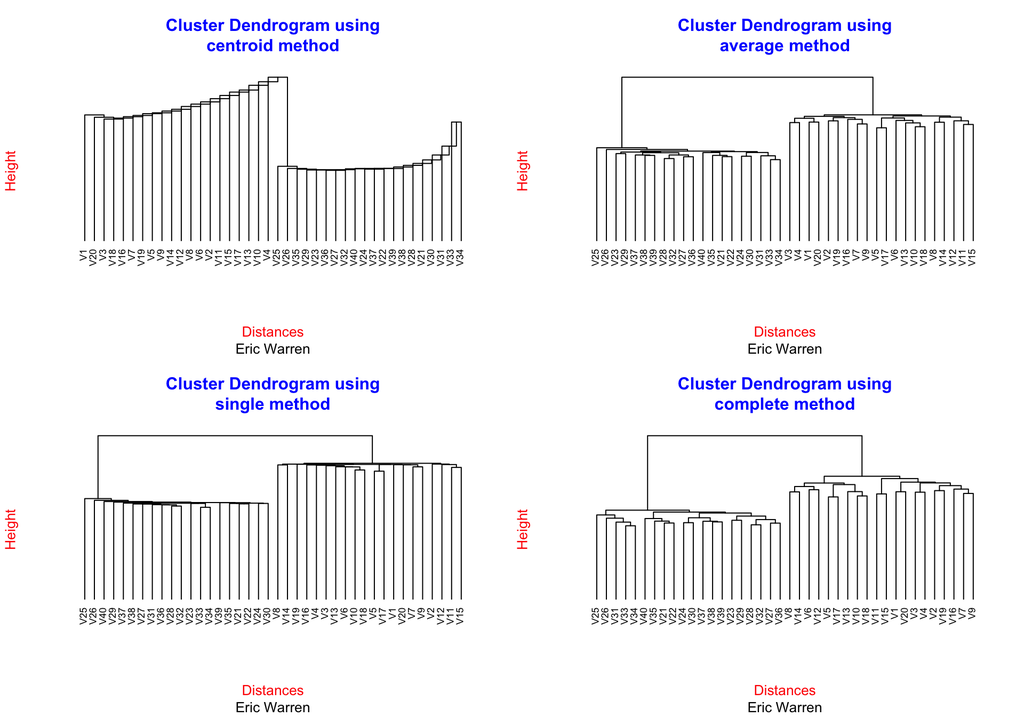

```r
# Find distances
Distances <- dist(cor(problem4_data))

methods <- c("centroid", "average", "single", "complete")

par(mfrow = c(2, 2))
for (i in methods) {
    clusters <- hclust(Distances, method = i)

    plot(clusters,
         col = "black",
         col.main = "blue",
         col.lab = "red",
         col.axis = "green",
         lwd = 1,
         lty = 1,
         cex = .69,
         sub = "Eric Warren",
         hang = -1,
         axes = FALSE,
         main = paste0("Cluster Dendrogram using\n", i,  " method"))
}
```

Here we can see that there are some extreme differences between the methods to perform clustering. We can see in all the method that there seems to be two distinctive groups. The type of linkage involved might affect the distances but it does not affect these two different groups. The Centroid method does have a weird looking second group.

#### Part C

Your collaborator wants to know which genes differ the most across the two groups. I am going to walk through a way to try to find it.

In order to see which variables differ the most between healthy and diseased patients I suggest the following: -Perform PCA on the data -Perform K-Means clustering on the first two dimensions and make plots to see if there is good separation on the components. -If there is such a difference, we will test to see if one group of genes is the one we are looking for.

Here we will use PCA.

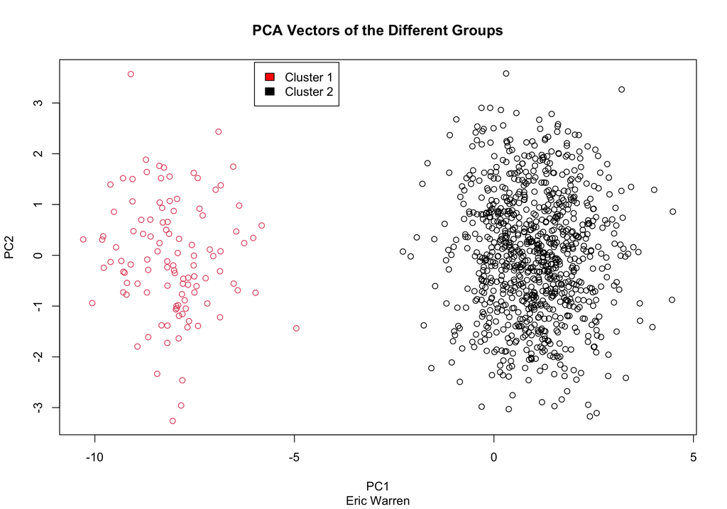

```r
set.seed(9)
par(mfrow = c(1, 1))
problem4_pca <- prcomp(problem4_data)

pca_data <- problem4_pca$x[ , 1:2] %>%
  as_tibble()

pca_kmeans <- kmeans(pca_data, centers = 2)

plot(pca_data,
     col = pca_kmeans$cluster,
     main = "PCA Vectors of the Different Groups",
     sub = "Eric Warren")
legend(-6, 3.8, legend = c("Cluster 1", "Cluster 2"),
       fill = c("red", "black"))
```

From this plot, we can see the two distinct different groups of genes that are present using what was described above.